# Ecological Inference and Racially Polarized Voting

A Georgia county where the inference can be checked against the ballots

Democracy’s Data

Last updated September 13, 2026 at 10:53a EDT

Section 2 of the Voting Rights Act, the part of the 1965 law that forbids election rules giving a racial minority less chance than other voters to elect the candidates it prefers,[^1] turns on a factual question: do voters of different races prefer different candidates? That pattern is called **racially polarized voting**. In *Thornburg v. Gingles*, 478 U.S. 30 (1986),[^2] the Supreme Court set three preconditions a plaintiff must establish: that the minority group is large and geographically compact enough to form a majority in a district, that its members vote alike, and that the majority usually votes as a bloc to defeat the candidate the minority prefers. The second and third are racially polarized voting, stated from each side. So a federal judge decides whether a districting plan stands by reading a percentage in an expert report.

Nobody records how you voted. What is recorded is how a *precinct* voted, the few thousand voters who share one polling place, and separately, who lives in that precinct. From those two totals an expert must work out how each racial group behaved, which is **ecological inference**: guessing what individuals did from group totals. In almost every county the answer cannot be checked afterwards by anyone.

In one kind of county it can. **What can precinct totals actually establish about how a racial group voted?**

## The test

Georgia makes two facts public that are private nearly everywhere else: the race a voter reports on the registration form, and which party’s primary ballot they requested. So for the General Primary of 21 May 2024 in Houston County, the quantity ecological inference exists to estimate is on record, person by person.

Three separate state records meet to produce that. Race comes off the **voter registration form**, where it sits because the Voting Rights Act obliged covered states to report who was registering. Party of the ballot comes from the **voter-history file**, because a state running partisan primaries has to record which one each voter took. Precinct comes from the **registration extract**, so a voter can be sent to the right polling place. Nobody built that answer key; it is a by-product of three unrelated obligations. Georgia sells all three to anyone who orders them (https://sos.ga.gov/page/order-voter-registration-lists-and-files), and the copy here is working data from the county’s 2026 redistricting matter, in which the instructor is retained. No material from any expert report is used.

This is the right evidence for grading a method and the wrong evidence for settling anything about the county’s politics. The recorded outcome is *which party’s ballot a voter asked for in a May primary*, not which candidate they supported in November. A general election with the same answer key would be better, and no such file can exist anywhere.

Everything below rests on one join, which is the subject of Join Keys and Crosswalks: what a join key is, and how one fails silently. It also covers the crosswalk, a table that translates one set of identifiers into another.

## The data

Three files, three offices, no shared purpose, and one thing in common: **a registration number**. That is the join key, and reading the counts downward shows how drastic it is.

| Step | Rows |
| --- | --- |
| Vote-history rows, 21 May 2024, D or R ballot | 17805 |
| Self-reported race, imputation removed, Black or white | 132452 |
| Registration extract rows carrying a precinct | 127560 |
| Joined on registration number, all three present | 16024 |
| Precinct rows written | 17 |

A voter has to be in all three files. They must have voted in that primary, reported a race rather than had one filled in for them, and still be in the registration extract with a precinct attached. Each condition is a judgment and each removes real voters. The last is the one nobody chooses: it drops anybody who has moved or died since May 2024.

Three exclusions were applied before the file was written. Voters whose race had been **filled in by a surname model** rather than reported were dropped, the same decision the BISG check brief makes: grading one guess against another produces a beautiful, meaningless result. A few hundred who took a ballot without requesting either party’s are counted as neither. And the analysis is restricted to voters who reported Black or white, which is standard Section 2 practice and is what makes a two-column method work.

What comes out is the thing ecological inference exists to reconstruct, so it is worth seeing once. Four real voters, with the registration number replaced by a row label:

| Voter | Party | Race self | Precinct |
| --- | --- | --- | --- |
| voter 1 | REPUBLICAN | White | ROZR |
| voter 2 | REPUBLICAN | White | CENT |
| voter 3 | DEMOCRAT | White | HHPC |
| voter 4 | REPUBLICAN | White | MCMS |

**Race, party, precinct — three columns, one voter per row, and the question is already answered.** Count the rows where race is Black and party is Democratic, divide by the rows where race is Black, and you have the number the rest of this brief estimates badly.

Then it disappears. Every voter-level row was replaced by totals before anything was saved, leaving 17 precinct rows with the columns `precinct`, `voters`, `black`, `white`, `dem` and `rep`. The cross-tabulation linking race to ballot is gone, and nothing in the precinct file recovers it. That is not an accident of this file; it is the condition of every Section 2 case ever litigated.

Two columns break that rule on purpose. `black_dem` and `white_dem` carry the counts the totals cannot give you, withheld from every method below and produced at the end as an answer key. **An expert witness has the rest of this table and does not have those two columns**, which is the whole difficulty, stated as a data structure.

| Quantity | Value |
| --- | --- |
| Precincts | 17 |
| Primary voters | 16,024 |
| Black voters | 4,631 |
| white voters | 11,393 |
| Democratic ballots requested | 5,106 |
| Republican ballots requested | 10,918 |
| Least Black precinct | HEFS (10.9% Black) |
| Most Black precinct | WELLSTON CENTER (76.6% Black) |

Note the last two rows. No precinct here is overwhelmingly Black, and that matters more than it looks.

> **Before you read on, write two things down.** The oldest method in voting-rights litigation, **homogeneous precinct analysis**, looks only at precincts that are nearly all one race and takes their totals as that group’s vote. There are none above 80% Black here, so it returns nothing at all.

> First, **your own estimate** of the share of Black voters who took a Democratic ballot. Second, and this is the question that matters: if a report handed you a fitted line with an R² of 0.982 — the fit statistic that runs from 0 to 1 and says how much of the scatter the line accounts for — and a clean scatter, **how far off would you expect its estimate to be?**

## What it says about democracy

The workhorse of Section 2 litigation for fifty years is Goodman’s ecological regression:[^3] fit a straight line through the precincts and read off its ends. Where the line crosses zero percent Black is the estimate for white voters; where it crosses one hundred percent is the estimate for Black voters.

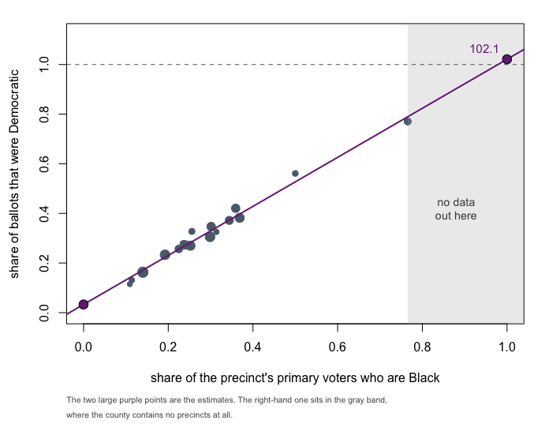

The two large purple points are the estimates. The right-hand one sits in the gray band, where the county contains no precincts at all.

**Figure 1. The fitted line, and where it has to go to produce an answer.** A scatter with the line drawn on it fits this question, because the answer is not a point in the data but the place where the line leaves it. One dot per precinct, sized by primary voters, and the two large points are the estimates at 0% and 100% Black. The gray band is the stretch of axis holding no precincts at all, everything above 76.6% Black. The dashed rule at the top is 100%, the ceiling of possibility.

**The model fits beautifully, with an R² of 0.982, and returns an impossible answer.** It estimates that 102.1% of Black voters took a Democratic ballot. A percentage above 100 is not a rounding problem; it is a signal that the method has been asked to do something it cannot do, and nothing in the fit statistics complained.

The gray band is why. The most Black precinct in the county is 76.6% Black, so the estimate for Black voters comes from extending the line 23 points past the last observation. The model is not summarising data out there. There is none.

There is a method that cannot be wrong, and its weakness is why nobody uses it alone. Duncan and Davis pointed out in 1953 that the precinct totals by themselves *limit* the answer,[^4] which is the **method of bounds**. One precinct shows how it works. WELLSTON CENTER had 772 primary voters, 591 Black and 181 white, and 595 of them asked for a Democratic ballot. Even if every one of the 181 white voters took a Democratic ballot, that accounts for only 181 of the 595; the other 414 had to come from Black voters, so at least 414 of the 591, or 70.1%, did. At the other end, all 595 Democratic ballots could have been Black voters’, and that is more than the precinct has, so the ceiling is 100%. Every precinct yields a floor and a ceiling like that, and they can be combined two ways. Add them up, each precinct’s floor and ceiling on the count of Black Democratic ballots over all 4,631 Black voters, and the county-wide rate is pinned between 9.6% and 100.0%: no assumptions, impossible to be wrong, and 90.4 points wide. Assume instead, as the regression does, that Black voters behave alike in every precinct, and that one rate must fit inside all 17 sets of limits at once, which narrows the range to 70.1% to 100.0%. That is the range Figure 2 draws, and it is still 29.9 points wide, which is why nobody testifies with it.

Now open the answer key.

| Method | Black voters | White voters |
| --- | --- | --- |
| Homogeneous precincts | cannot be computed | 18.0% |
| Goodman’s regression | 102.1% | 3.3% |
| Bounds, lower | 70.1% |  |
| Bounds, upper | 100.0% |  |
| THE TRUTH | 92.7% | 7.1% |

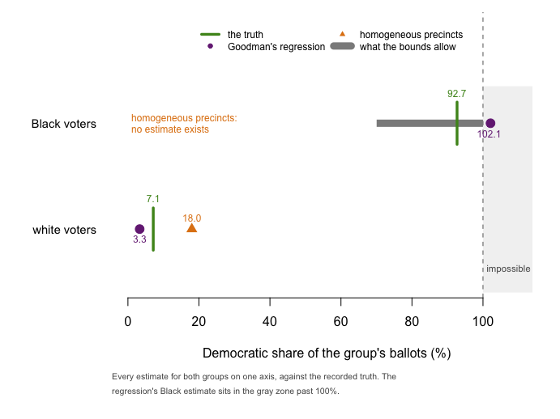

Every estimate for both groups on one axis, against the recorded truth. The regression’s Black estimate sits in the gray zone past 100%.

**Figure 2. Every estimate, against the recorded truth.** One row per group: the thick bar is what the bounds allow, the dot is Goodman’s estimate, the triangle is the homogeneous-precinct answer, and the vertical rule is what the voter file recorded. The shaded zone past 100% is impossible, and the regression’s Black estimate sits inside it.

**The truth is 92.7% for Black voters and 7.1% for white voters.** This electorate is about as polarized as American politics gets, and every method got the direction right. Look at how. The bounds contained the truth, at a cost of 29.9 points of precision. Goodman missed by 9.4 points and landed outside the range of possible numbers, its white estimate of 3.3% being less than half the true 7.1%. The homogeneous-precinct route could not answer for Black voters at all, and overstated white Democratic support by 10.9 points.

**The method that was most confident was the one that was wrong, and its confidence was legible.** The impossibility was the only warning, and only because the truth sat near a boundary. Had Black Democratic support been 60%, Goodman could have missed by the same margin and returned a plausible 51%, and nobody would ever have known.

The failure is not that the model fits badly. It predicts every precinct’s Democratic share to within 4.2 points and still misstates the group rate by 9.4. **Predicting the total and taking the total apart are different problems.** That is the **ecological fallacy**, reading what individuals did off the totals of the groups they belong to,[^5] shown rather than asserted.

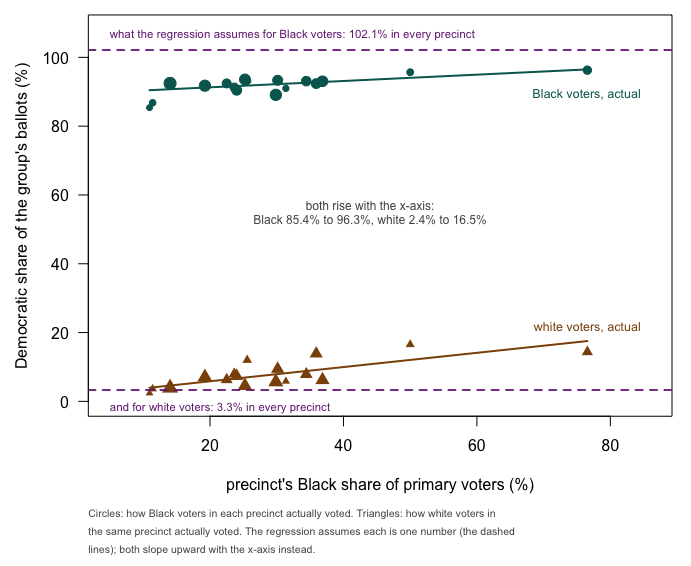

Circles: how Black voters in each precinct actually voted. Triangles: how white voters in the same precinct actually voted. The regression assumes each is one number (the dashed lines); both slope upward with the x-axis instead.

**Figure 3. The assumption the regression makes, and what was actually true.** Circles are how Black voters in each precinct actually voted and triangles are how white voters did, both against how Black the precinct is. The dashed rules are what the regression assumes: one number per group, the same everywhere.

Both true rates slope upward instead. The Black rate runs from 85.4% to 96.3%, correlated 0.72 with the precinct’s Black share, and the white rate from 2.4% to 16.5%. **Black voters are more Democratic in precincts with more Black voters.** That link between how a group behaves and how large it is locally is exactly the condition under which the method breaks, and it cannot be detected from totals. From outside it looks like a slightly steeper line.

The whole thing also rests on one polling place. WELLSTON CENTER is the only precinct above 50% Black, so it anchors the right-hand end of the line. Refit 17 times, leaving one precinct out each time, and the estimate ranges over 5.8 points and stays above 100% in 17 of the 17 refits, moving furthest when WELLSTON CENTER is the one left out. **A fifty-year-old courtroom standard, in this county, rests on one polling place,** and no report states how many precincts anchor the minority end of a line.

## What this brief cannot tell you

**None of this establishes the *Gingles* preconditions any more.** *Louisiana v. Callais*, 608 U.S. ___ (2026), did not overrule *Gingles* but updated it, and the update lands on the two preconditions this brief is about. A plaintiff must now “provide an analysis that controls for party affiliation” and show racial bloc voting “that cannot be explained by partisan affiliation.”[^6] The only outcome recorded here is which party’s ballot a voter asked for, which is the between-party comparison in its purest form. That is exactly the comparison the Court now says proves nothing on its own.

**Seventeen precincts, one primary, two groups.** A primary ballot request is not a November vote, and primary electorates are smaller and more partisan. Everyone who is not Black or white was dropped for want of a box to put them in. They voted; the framework excluded them, not the data.

**Race on the form is itself a measurement**, with the one-box problem every self-reported race question has. And Gary King’s 1997 method, known in the field simply as **EI** and the standard tool in current litigation, was not run here.[^7] It uses the bounds as hard limits and a model to locate the answer inside them, so it would do better. It would also still be a model, uncheckable in every county but this kind.

**The validation comes from a biased set of counties.** Checking these methods needs a state that records race *and* runs partisan primaries: a small, mostly Southern set, and also where Section 2 litigation concentrates.

## What you should have learned

- The precinct totals cannot be taken apart. `black_dem` and `white_dem` exist here only because Georgia records both race and party of ballot, which almost nowhere else does.
- The method courts trust most returned nothing. No precinct here reaches 80% Black, the most Black being 76.6%, so a homogeneous-precinct estimate for Black voters does not exist.
- Ecological regression fit with an R² of 0.982 and estimated 102.1% against a recorded truth of 92.7%: 9.4 points off, and past the ceiling of possibility.
- The bounds cannot decide anything. With no assumption at all they allow 9.6% to 100.0%; assuming one county-wide rate, as the regression does, 70.1% to 100.0%, still 29.9 points wide.
- Goodman’s line assumes each group behaves the same everywhere. Here the Black Democratic rate runs from 85.4% to 96.3%, correlated 0.72 with the very variable on the horizontal axis.

## Extensions

None of these is answered above, and every one can be answered by sorting or grouping the tables the Sources section hands over.

- `houston_primary.csv` has `black`, `white`, `dem` and `rep` per precinct. Compute the Democratic share and the Black share, and sort one against the other.
- The same file carries `black_dem` and `white_dem`, the truth. Compute each precinct’s own Black Democratic rate, and find where one county-wide number goes furthest wrong.
- `join_counts.csv` counts the rows surviving each step of the join. Work out what share of the first `step` is left at the end, and say who fell out.
- `join_peek.csv` shows four joined voter records. Write down which source file supplied each column, and what breaks if one of them lacks the registration number.

Two stretch ideas point past the spreadsheet. North Carolina also records race on registration and runs partisan primaries; build the same precinct file there and see whether the line fails the same way. And *Gingles* rested on divergence *inside* one primary rather than between the parties, so work out what a party-controlled analysis would need.

## Sources

**Data**

- Houston County, Georgia, General Primary of 21 May 2024: party of the ballot requested from the state’s voter-history file, race self-reported on the registration form, precinct from the registration extract. Georgia sells all three to anyone who orders them. https://sos.ga.gov/page/order-voter-registration-lists-and-files The copy used here is working data for the county’s 2026 redistricting matter, in which the instructor is retained; no material from any expert report is used. **Rows whose race had been filled in by a surname model were dropped** before the collapse to precinct level.

**Literature and cases**

- Goodman, L. A. (1953). “Ecological Regressions and Behavior of Individuals.” *American Sociological Review* 18(6): 663–664. https://www.jstor.org/stable/2088121
- Duncan, O. D. and Davis, B. (1953). “An Alternative to Ecological Correlation.” *American Sociological Review* 18(6): 665–666. https://www.jstor.org/stable/2088122
- Robinson, W. S. (1950). “Ecological Correlations and the Behavior of Individuals.” *American Sociological Review* 15(3): 351–357. The ecological fallacy, named. https://doi.org/10.2307/2087176
- Freedman, D. A. et al. (1991). “Ecological Regression and Voting Rights.” *Evaluation Review* 15(6): 673–711. doi:10.1177/0193841X9101500601
- King, G. (1997). *A Solution to the Ecological Inference Problem.* Princeton University Press. https://gking.harvard.edu/eicamera/kinroot.html
- *Thornburg v. Gingles*, 478 U.S. 30 (1986). https://www.law.cornell.edu/supremecourt/text/478/30
- *Louisiana v. Callais*, 608 U.S. ___ (2026), Nos. 24-109 and 24-110, decided 29 April 2026. https://www.supremecourt.gov/opinions/25pdf/24-109_21o3.pdf
- Section 2 of the Voting Rights Act, 52 U.S.C. § 10301. https://www.law.cornell.edu/uscode/text/52/10301

**The data itself**

Every figure above is drawn from these tables. They are plain CSV, they open in a spreadsheet, and they are yours to take further.

`houston_primary.csv`, `join_counts.csv`, `join_peek.csv`

[^1]: 52 U.S.C. § 10301: https://www.law.cornell.edu/uscode/text/52/10301.
[^2]: https://www.law.cornell.edu/supremecourt/text/478/30.
[^3]: Leo A. Goodman, “Ecological Regressions and Behavior of Individuals,” *American Sociological Review* 18, no. 6 (1953): 663–664, https://www.jstor.org/stable/2088121.
[^4]: Otis Dudley Duncan and Beverly Davis, “An Alternative to Ecological Correlation,” *American Sociological Review* 18, no. 6 (1953): 665–666, https://www.jstor.org/stable/2088122.
[^5]: W. S. Robinson, “Ecological Correlations and the Behavior of Individuals,” *American Sociological Review* 15, no. 3 (1950): 351–357, https://doi.org/10.2307/2087176.
[^6]: *Louisiana v. Callais*, No. 24-109, slip op. at 30 (U.S. Apr. 29, 2026), https://www.supremecourt.gov/opinions/25pdf/24-109_21o3.pdf.
[^7]: Gary King, *A Solution to the Ecological Inference Problem: Reconstructing Individual Behavior from Aggregate Data* (Princeton: Princeton University Press, 1997), https://gking.harvard.edu/eicamera/kinroot.html.